# Weight Lifting Exercise Quality Machine Learning Model

Jason Naramore

## Summary

The purpose of this assignment is to quantify the quality of weight lifting exercises. Data was collected as described in the reference [1] using 3-axes acceleration, gyroscope, and magnetometer sensors attached to a subject’s wrist, upper arm, waist, and dumbbell. Each subject performed Unilateral Dumbbell Bicep Curls that were classified as follows:

A: exactly according to the specification,  
B: throwing the elbows to the front,  
C: lifting the dumbbell only halfway,  
D: lowering the dumbbell only halfway,  
E: throwing the hips to the front.

A random forest model was trained to accurately identify each of these classifications using the relevant sensor data. The out of sample accuracy was estimated using 10% of the training data that was set aside prior to training.

## Step 1 - Load and Subset

First, the training and test sets are loaded. The training set is then subsetted to columns where there are not NA values in the testing set. Also, the first 7 columns are ignored, which contain subject identifiers, timestamps, and other unneeded variables for training. The training set is partitioned into two groups, one containing 90% of the rows to be used for training, and the remaining 10% will be used to estimate the accuracy of the model.

```r
library(caret)
training<-read.csv("pml-training.csv")
testing<-read.csv("pml-testing.csv")

#only consider columns that appear in testing
na_mask <- is.na(testing[1,])
training1<-subset(training,select = !na_mask)
training1<-subset(training1,select = c(-1:-7))

testing1 <- subset(testing,select = !na_mask)
testing1 <- subset(testing1,select = c(-1:-7))

set.seed(1234)
trainIn<- createDataPartition(training1$classe, p = .9,list=FALSE)
training2<- training1[trainIn,]
training2_test<- training1[-trainIn,]
```

## Step 2 - PCA

```r
preProc<-preProcess(training2[,-53],method = "pca",thresh = .8)
trainPC <- predict(preProc,training2[,-53])
```

## Step 3 - Fit Random Forest Model

```r
fitControl <- trainControl(method = "cv")
set.seed(1234)
modFit<-train(y = training2$classe, x = trainPC,method = "rf",trControl = fitControl)
modFit
```

```
## Random Forest
##
## 17662 samples
##    12 predictor
##     5 classes: 'A', 'B', 'C', 'D', 'E'
##
## No pre-processing
## Resampling: Cross-Validated (10 fold)
## Summary of sample sizes: 15896, 15895, 15895, 15896, 15894, 15897, ...
## Resampling results across tuning parameters:
##
##   mtry  Accuracy   Kappa
##    2    0.9680107  0.9595364
##    7    0.9618393  0.9517335
##   12    0.9575358  0.9462956
##
## Accuracy was used to select the optimal model using the largest value.
## The final value used for the model was mtry = 2.
```

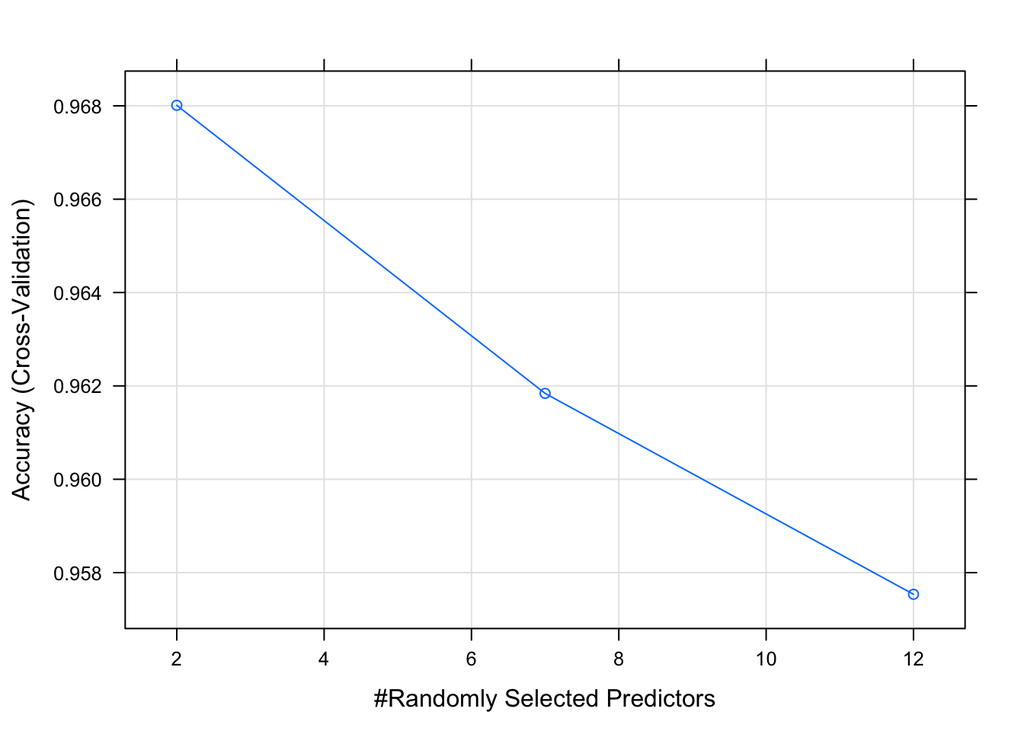

Estimated Accuracy by Resampling

```r
plot(modFit)
```

## Step 3.1 - Plot Variable Importance

The importance of each principal components is shown in the plot below.

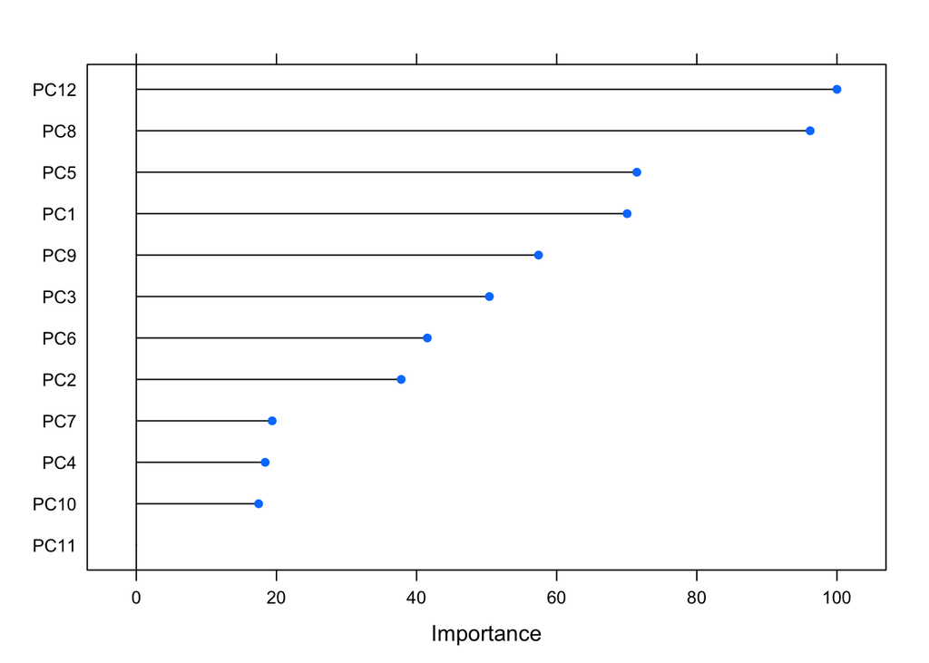

Variable Importance in The Random Forest Model

```r
plot(varImp(modFit))
```

## Step 4.1 - Results of Training Set

The final model classifies the training set with 100% accuracy.

```r
train_pred <- predict(modFit,trainPC)
confusionMatrix(train_pred,factor(training2$classe))
```

```
## Confusion Matrix and Statistics
##
##           Reference
## Prediction    A    B    C    D    E
##          A 5022    0    0    0    0
##          B    0 3418    0    0    0
##          C    0    0 3080    0    0
##          D    0    0    0 2895    0
##          E    0    0    0    0 3247
##
## Overall Statistics
##
##                Accuracy : 1
##                  95% CI : (0.9998, 1)
##     No Information Rate : 0.2843
##     P-Value [Acc > NIR] : < 2.2e-16
##
##                   Kappa : 1
##
##  Mcnemar's Test P-Value : NA
##
## Statistics by Class:
##
##                      Class: A Class: B Class: C Class: D Class: E
## Sensitivity            1.0000   1.0000   1.0000   1.0000   1.0000
## Specificity            1.0000   1.0000   1.0000   1.0000   1.0000
## Pos Pred Value         1.0000   1.0000   1.0000   1.0000   1.0000
## Neg Pred Value         1.0000   1.0000   1.0000   1.0000   1.0000
## Prevalence             0.2843   0.1935   0.1744   0.1639   0.1838
## Detection Rate         0.2843   0.1935   0.1744   0.1639   0.1838
## Detection Prevalence   0.2843   0.1935   0.1744   0.1639   0.1838
## Balanced Accuracy      1.0000   1.0000   1.0000   1.0000   1.0000
```

## Step 4.2 - Results of Training-Test Set

```r
trainPCtest<-predict(preProc,training2_test[,-53])
train2test_pred <- predict(modFit,trainPCtest)
confusionMatrix(train2test_pred,factor(training2_test$classe))
```

```
## Confusion Matrix and Statistics
##
##           Reference
## Prediction   A   B   C   D   E
##          A 549   5   1   1   0
##          B   1 358   7   1   2
##          C   3  11 327   8   2
##          D   5   3   7 310   6
##          E   0   2   0   1 350
##
## Overall Statistics
##
##                Accuracy : 0.9663
##                  95% CI : (0.9574, 0.9739)
##     No Information Rate : 0.2847
##     P-Value [Acc > NIR] : < 2.2e-16
##
##                   Kappa : 0.9574
##
##  Mcnemar's Test P-Value : NA
##
## Statistics by Class:
##
##                      Class: A Class: B Class: C Class: D Class: E
## Sensitivity            0.9839   0.9446   0.9561   0.9657   0.9722
## Specificity            0.9950   0.9930   0.9852   0.9872   0.9981
## Pos Pred Value         0.9874   0.9702   0.9316   0.9366   0.9915
## Neg Pred Value         0.9936   0.9868   0.9907   0.9932   0.9938
## Prevalence             0.2847   0.1934   0.1745   0.1638   0.1837
## Detection Rate         0.2801   0.1827   0.1668   0.1582   0.1786
## Detection Prevalence   0.2837   0.1883   0.1791   0.1689   0.1801
## Balanced Accuracy      0.9894   0.9688   0.9707   0.9765   0.9852
```

## Step 5 - Predict Testing Set

The last step is to predict the testing set. The classe is unknown in the testing set.

```r
testPC<-predict(preProc,testing1[,-53])
test_prediction <- predict(modFit,testPC)
factor_levels <- levels(factor(training$classe))
test_predict_factors <- factor_levels[test_prediction]
data.frame(problem_id = testing1$problem_id, test_predict_factors)
```

```
##    problem_id test_predict_factors
## 1           1                    B
## 2           2                    A
## 3           3                    A
## 4           4                    A
## 5           5                    A
## 6           6                    E
## 7           7                    D
## 8           8                    B
## 9           9                    A
## 10         10                    A
## 11         11                    A
## 12         12                    C
## 13         13                    B
## 14         14                    A
## 15         15                    E
## 16         16                    E
## 17         17                    A
## 18         18                    B
## 19         19                    B
## 20         20                    B
```

## References

[1] Velloso, E.; Bulling, A.; Gellersen, H.; Ugulino, W.; Fuks, H. Qualitative Activity Recognition of Weight Lifting Exercises. Proceedings of 4th International Conference in Cooperation with SIGCHI (Augmented Human ’13) . Stuttgart, Germany: ACM SIGCHI, 2013. Website: http://groupware.les.inf.puc-rio.br/har#ixzz6kg2ypyaf